# SPPH 501 Term Project: Shared Frailty Models for Recurrent Events and a Terminal Event

Nov 18, 2019

## Outline

1. COPD datasets
2. Recurrent events and a terminal event
3. Covariates
4. Joint/shared frailty model
5. Results

## What is Chronic Obstructive Pulmonary Disease (COPD)?

- COPD is characterized by coughing and shortness of breath, usually caused by two mechanisms: 1) damaged alveoli 2) damaged bronchial tubes.
- An excerbation is a sudden worsening or flare-up of the COPD symtoms. It could take a month or longer to recover completely from it.

[figure not shown]

  (Nation-Jewish-Health n.d.)

## MACRO and OPTIMAL Clinical Datasets

- The data is composed of two *randomized* clinical datasets: MACRO (Albert et al. 2011) and OPTIMAL (Aaron et al. 2007).
- For each trial, there is a control group (placebo) and treatment groups (drugs).
- The response variable in these studies is the exacerbation rate, defined as the number of COPD exacerbations per year. Note that there are different levels of COPD excerbation (mild and severe).
- The purpose of these studies is to investigate the effects of drugs on excerbation rate.

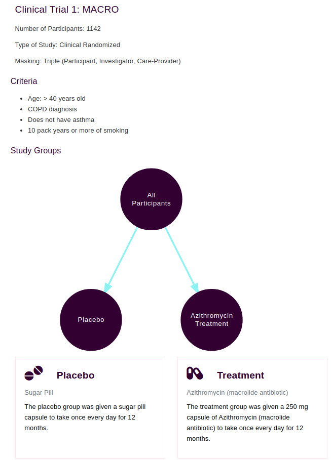

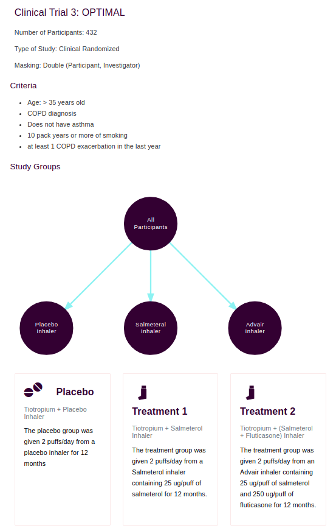

## Recurrent Events and a Terminal Event

```
##  recurrent_event num_recurrent_events death
##  0:1523          0      :1523         0:1911
##  1: 458          1      : 311         1:  70
##                  2      :  83
##                  3      :  37
##                  4      :  13
##                  5      :   7
##                  (Other):   7
```

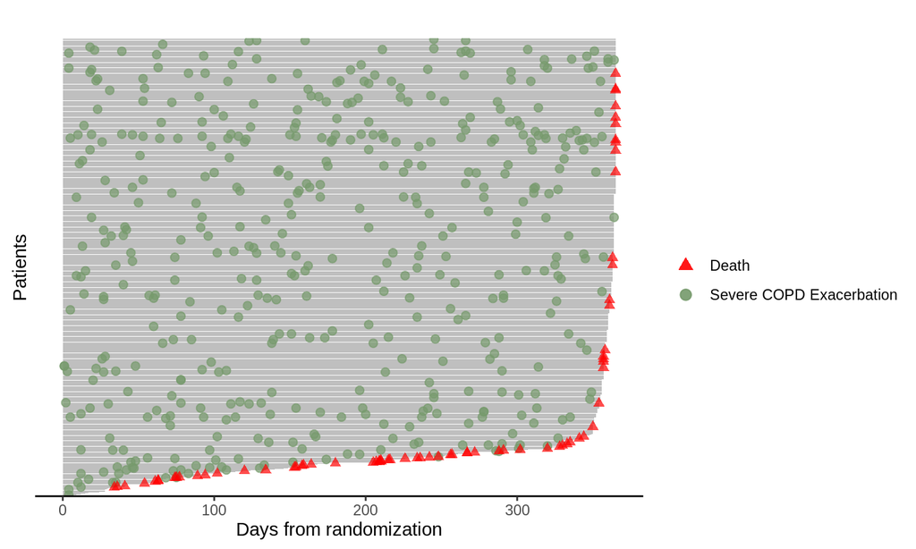

## By Gender (1:Female, 2:Male)

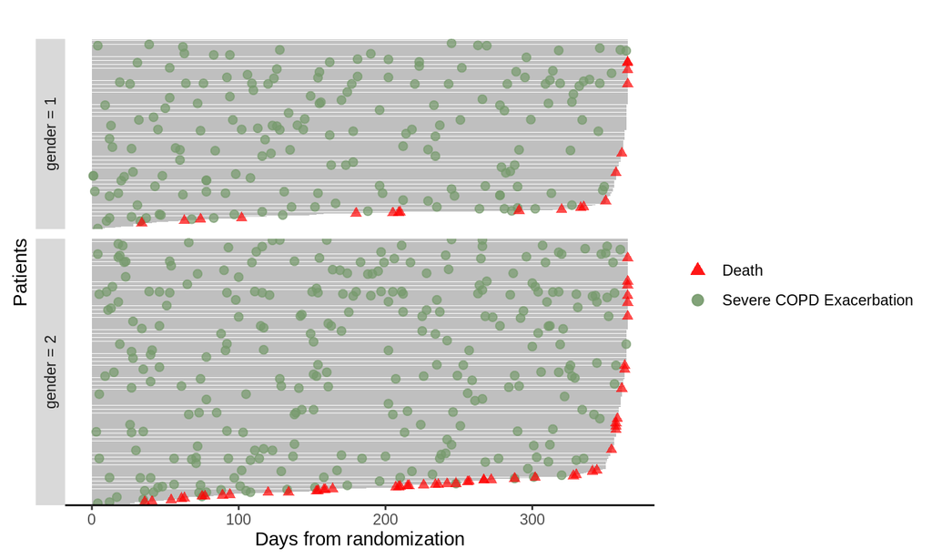

## By Treatment Group (1:Placebo, 2: Drug A , 3: Drug B)

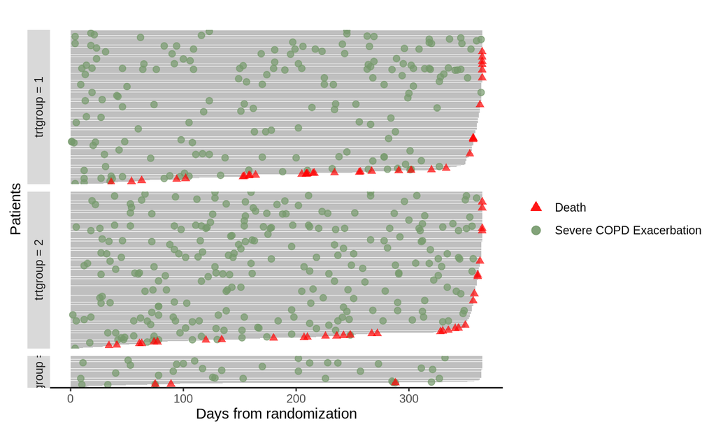

## Cumulative Sample Mean (CSM)

CSM(t)=\(\frac{1}{n}\sum_{i=1}^n N_i(t),\) where \(N_i(t)=\)# of events of interest over the time interval \([0,t]\) for patient \(i\) (Cook and Lawless 2007).

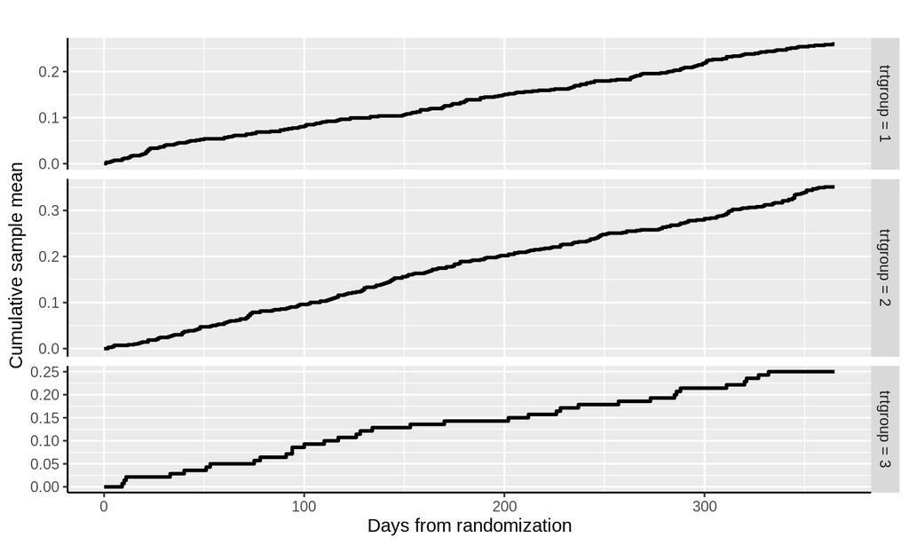

## Baseline Covariates

|  | Days_In_Study | OPTIMAL | trtgroup | gender | age | BMI |
| --- | --- | --- | --- | --- | --- | --- |
|  | Min. : 7 | 0:1106 | 1:685 | 0:634 | Min. :40.66 | Min. :13.91 |
|  | 1st Qu.:356 | 1: 417 | 2:698 | 1:889 | 1st Qu.:60.00 | 1st Qu.:23.51 |
|  | Median :363 |  | 3:140 |  | Median :66.00 | Median :26.77 |
|  | Mean :337 |  |  |  | Mean :65.92 | Mean :27.70 |
|  | 3rd Qu.:365 |  |  |  | 3rd Qu.:72.00 | 3rd Qu.:31.31 |
|  | Max. :365 |  |  |  | Max. :89.00 | Max. :54.56 |

## Lung-related Covariates

|  | nowsmk | oxygen | fev1pp | fev1 | fvc | packyears |
| --- | --- | --- | --- | --- | --- | --- |
|  | 0:1167 | 0:818 | Min. : 9.00 | Min. :0.150 | Min. :0.690 | Min. : 4.00 |
|  | 1: 356 | 1:705 | 1st Qu.:28.15 | 1st Qu.:0.720 | 1st Qu.:1.965 | 1st Qu.: 36.00 |
|  |  |  | Median :38.78 | Median :0.970 | Median :2.450 | Median : 50.00 |
|  |  |  | Mean :40.09 | Mean :1.082 | Mean :2.587 | Mean : 56.31 |
|  |  |  | 3rd Qu.:51.00 | 3rd Qu.:1.330 | 3rd Qu.:3.100 | 3rd Qu.: 74.00 |
|  |  |  | Max. :85.41 | Max. :3.200 | Max. :6.450 | Max. :230.00 |

## Randomization Dates

```
##    Rand_Date       rand_month  rand_season rand_seasonality
##  Min.   :15984   11     :151   1:359       0:748
##  1st Qu.:16390   4      :150   2:384       1:775
##  Median :17190   10     :150   3:364
##  Mean   :17080   3      :141   4:416
##  3rd Qu.:17572   8      :140
##  Max.   :18043   5      :132
##                  (Other):659
```

- Severe COPD exacerbation dates:

```
##  event_season event_seasonality
##  1:150        0:196
##  2:104        1:262
##  3: 92
##  4:112
```

- Death dates:

```
##  event_season event_seasonality
##  1:15         0:39
##  2:19         1:31
##  3:20
##  4:16
```

## Number of Previous Severe COPD Exacerbations

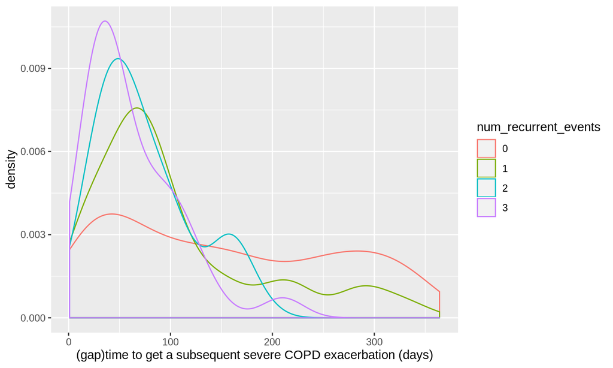

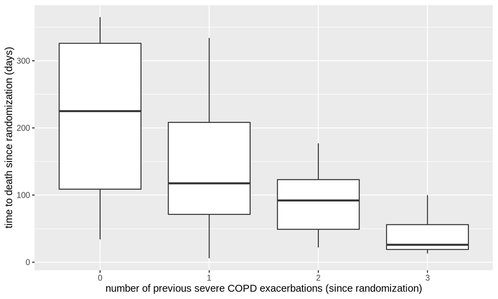

## Why Joint Modeling?

- We see that the follow-up of the patients was terminated by death, meaning that any subsequent severe COPD exacerbation cannot occur.
- The exploratory data analysis shows that death could be **correlated** with severe COPD exacerbations; the recurrence of severe COPD exacerbations could increase the risk of death.
- Joint/shared frailty (random effects) models allow one to study the two processes together.

## Frailty Models

- Proportional Cox hazard models are frailty models without random effects: \[\lambda_{ij}(t)= \lambda_0(t) \exp(\beta^T X_{ij}),\] where \(\lambda_0(\cdot)\) is the baseline hazard function.
- Adding random effects, you get a (gamma) frailty model: \[\lambda_{ij}(t|v_i)= \lambda_0(t) \exp(\beta^T X_{ij}+\log(v_i)),\] where \(v_i \sim^d \Gamma(1/\theta,1/\theta)\) are i.i.d. Note that that \(E(v_i)=1\) and \(Var(v_i)=\theta\).
- Under this specification, the likelihood has an analytical form (Cook and Lawless 2007).

## Joint/shared Frailty models

- A joint frailty model of the recurrent events (RE) and a terminal event is characterized by two hazard functions: \[\mbox{(RE) } r_{ij}(s|v_i) = v_i r_0(s) \exp(\beta_r^T X_{ij})\] and \[ \mbox{(death) } \lambda_{i}(t|v_i) = v_i^\alpha \lambda_0(t) \exp(\beta_d^T X_{i}), ~\alpha \geq 0.\]
- \(s\) is the gaptime; \(s_{ij}=T_{ij}-T_{i(j-1)}, T_{i0}=0\) for patient \(i\) and \(j\)th gaptime.
- Notice that the frailty term, \(v_i\), is **shared** by the two processes.

## Meaning of the frailty term

- The dependence in this model is characterized by \((\alpha,\theta)\).
- Suppose \(\theta\) is not null (if it is, then two processes are independent and \(\alpha\) has no meaning).
- If \(\alpha=0\), then there is no dependence attributable to unobserved covariates (i.e. no depedence given observed covariates).
- If \(\alpha>0\), then \(\theta\) not only accounts for heterogeniety in patients but describes the dependence (attributable to unobserved covariates) between the two processes through \(\alpha\).

## Choice of Baseline Hazard Functions and \(v_i\)

- There are many choices available for frailty models but not so many for shared frailty models. Likelihood of the shared fraitly models does not have an analytical form.
- I experimented with several *packages* in **R** and **SAS**; they have different estimation methods.
- For joint frailty models, I tried *frailtypack* (Rondeau et al. 2007) in **R** and the approach using *NLMIXED* in **SAS** by Liu and Huang (2008) (this is the approach taken by Sadatsafavi et al. (2018)).
- Rondeau et al. (2007) proposed a numerical method for frailty and shared frailty models with nonparametric hazard functions (using splines) with the gamma frailty.
- Liu and Huang (2008) proposed the use of Gaussian quadrature for parametric (standard Weibull) and piece-wise hazard functions in frailty and shared frailty models. In this framework, \(v_i\) can chosen more flexibly (through transformation techniques). I used Normal(0,\(\sigma^2\)) in addition to the standard gamma frailty.
- To check the validity of those two methods , I also used *parfm* (Munda et al. 2012) in **R** for parametric hazard functions (Weibull) with the gamma frailty in simple frailty models.
- Note that for parametric hazard functions, using the gamma frailty leads to an analytical form of the likelihood (Cook and Lawless 2007); standard optimzation techniques can be used to estimate the parameters.
- I ran into errors when I used *frailtypack* for shared frailty models… It has many practical barriers.

## SAS Code

```r
# PROC NLMIXED DATA=WORK.copd GCONV=0 QPOINTS=6 GTOL=1E-8 COV CORR;
#   PARMS /* Initial values for the parameters */
#   lin=b_0+...+b_p X_p + z;
#   alpha=EXP(lin);
#   S_t=exp(-(alpha*gaptime)**EXP(ln_gamma));
#   h=EXP(ln_gamma)*alpha*((gaptime*alpha)**(EXP(ln_gamma)-1));
#   ll1=(recurrent_event~=1)*log(S_t)+(recurrent_event=1)*log(h*S_t);
#   lin_d=b_d_0 +   ... + d_q X_q + z/kinv;
#   alpha_d=EXP(lin_d);
#   S_t_d=exp(-(alpha_d*gaptime)**EXP(ln_gamma_d));
#   h_d=EXP(ln_gamma_d)*alpha_d*((gaptime*alpha_d)**(EXP(ln_gamma_d)-1));
#   ll2=(death~=1)*log(S_t_d)+(death=1)*log(h_d*S_t_d);
#   ll=ll1+ll2;
#   MODEL gaptime~general(ll);
#   RANDOM z~NORMAL(0,EXP(ln_v)) SUBJECT=ID;
```

## RE Frailty Model: Paramter Estimates

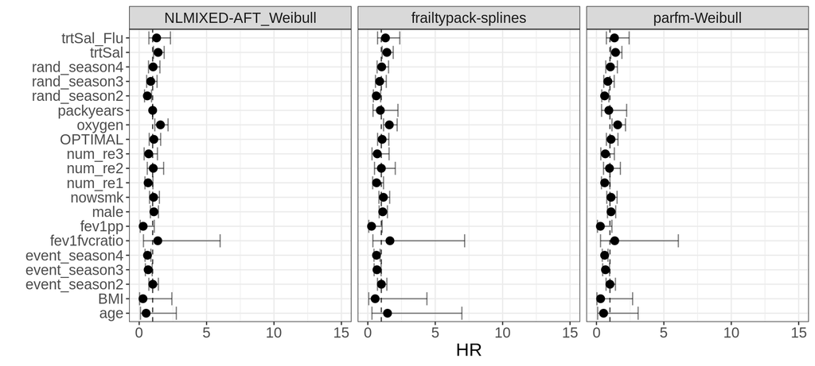

## RE Frailty Model: Frailty Estimates

| Model | Estimate | StandardError |
| --- | --- | --- |
| NLMIXED-AFT_Weibull | 2.60 | 0.55 |
| frailtypack-splines | 3.10 | 1.20 |
| parfm-Weibull | 3.28 | 0.95 |

## Death Frailty Model: Parameter Estimates

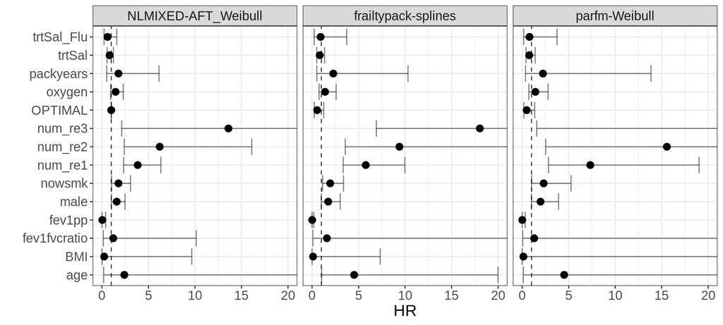

## Death Fraiilty Model: Frailty Estimates

| Model | Estimate | StandardError |
| --- | --- | --- |
| NLMIXED-AFT_Weibull | 1.16 | 2.41 |
| frailtypack-splines | 0.00 | 0.03 |
| parfm-Weibull | 2.96 | 4.59 |

## Joint Frailty Model: RE Parameter Estimates

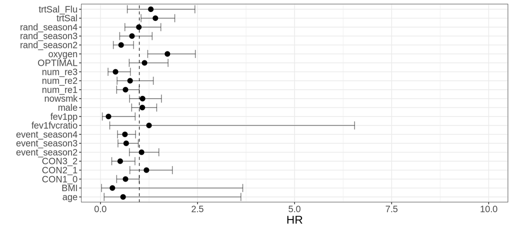

## Joint Frailty Model: Death Parameter Estimates

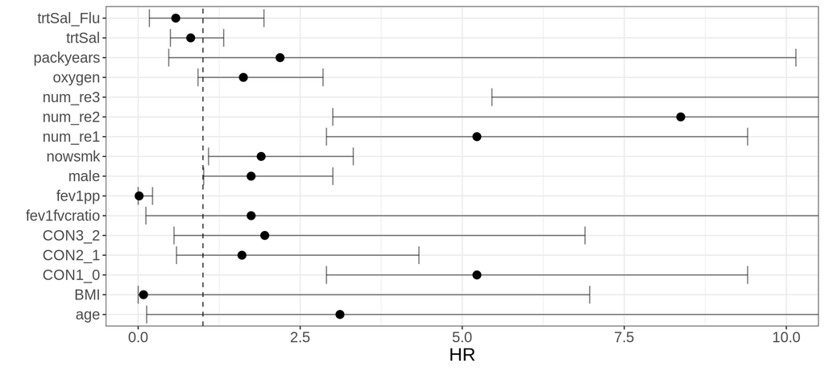

## Joint Frailty Model: Frailty Estimates

| Label | Estimate | StandardError |
| --- | --- | --- |
| \(\alpha\) | 0.02 | 0.06 |
| \(\sigma^2\) | 1.96 | 0.36 |

## Association of Severe COPD exacerbation on the risk of its subsequent one

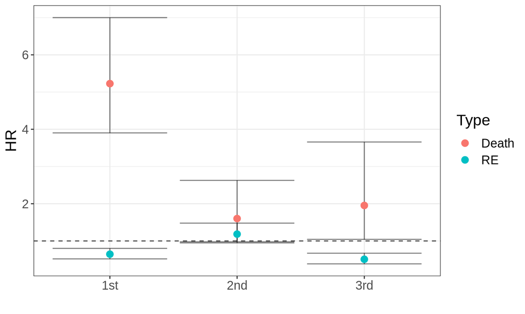

## References

Aaron, Shawn D., Katherine L. Vandemheen, Dean Fergusson, François Maltais, Jean Bourbeau, Roger Goldstein, Meyer Balter, Denis O’Donnell, Andrew McIvor, and Sat Sharma. 2007. “Tiotropium in Combination with Placebo, Salmeterol, or Fluticasone–Salmeterol for Treatment of Chronic Obstructive Pulmonary Disease: A Randomized Trial.” *Annals of Internal Medicine* 146 (8): 545–55.

Albert, Richard K., John Connett, William C. Bailey, Richard Casaburi, J. Allen D. Cooper, Gerard J. Criner, Jeffrey L. Curtis, et al. 2011. “Azithromycin for Prevention of Exacerbations of COPD.” *The New England Journal of Medicine* 365 (8): 689–98. https://doi.org/10.1056/NEJMoa1104623.

Cook, Richard J., and Jerald Lawless. 2007. *The Statistical Analysis of Recurrent Events*. Springer Science & Business Media.

Liu, Lei, and Xuelin Huang. 2008. “The Use of Gaussian Quadrature for Estimation in Frailty Proportional Hazards Models.” *Statistics in Medicine* 27 (14): 2665–83.

Munda, Marco, Federico Rotolo, Catherine Legrand, and others. 2012. “Parfm: Parametric Frailty Models in R.” *Journal of Statistical Software* 51 (11). Foundation for Open Access Statistics: 1–20.

Nation-Jewish-Health. n.d. “COPD Overview.” *National Jewish Health*. Accessed November 19, 2019. https://nationaljewish.org/conditions/copd-chronic-obstructive-pulmonary-disease/overview.

Rondeau, Virginie, Simone Mathoulin-Pelissier, Hélène Jacqmin-Gadda, Véronique Brouste, and Pierre Soubeyran. 2007. “Joint Frailty Models for Recurring Events and Death Using Maximum Penalized Likelihood Estimation: Application on Cancer Events.” *Biostatistics* 8 (4): 708–21. https://doi.org/10.1093/biostatistics/kxl043.

Sadatsafavi, Mohsen, Hui Xie, Mahyar Etminan, Kate Johnson, J. Mark FitzGerald, and Canadian Respiratory Research Network. 2018. “The Association Between Previous and Future Severe Exacerbations of Chronic Obstructive Pulmonary Disease: Updating the Literature Using Robust Statistical Methodology.” *PloS One* 13 (1): e0191243. https://doi.org/10.1371/journal.pone.0191243.

Suissa, Samy, Sophie Dell’Aniello, and Pierre Ernst. 2012. “Long-Term Natural History of Chronic Obstructive Pulmonary Disease: Severe Exacerbations and Mortality.” *Thorax* 67 (11): 957–63. https://doi.org/10.1136/thoraxjnl-2011-201518.